# W3cubDocs

/Matplotlib 3.1

# matplotlib.mathtext

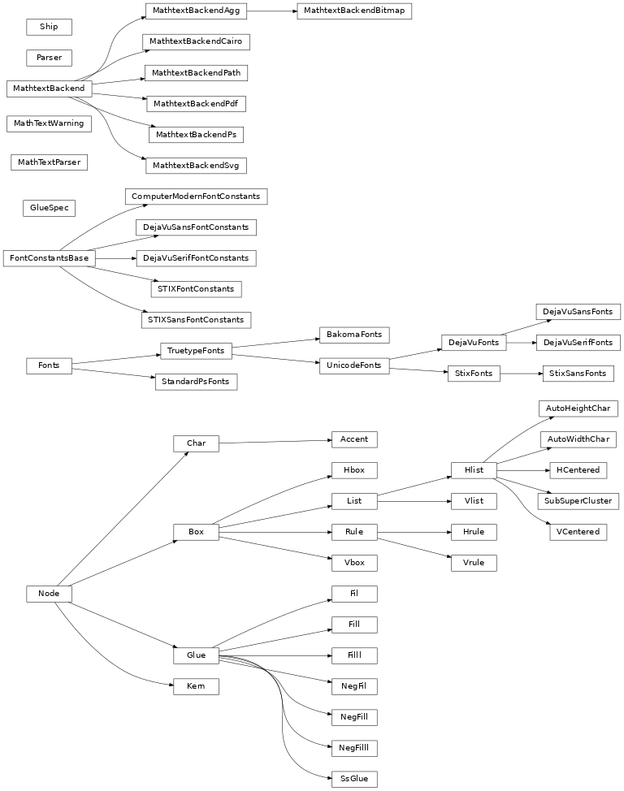

`mathtext` is a module for parsing a subset of the TeX math syntax and drawing them to a matplotlib backend.

For a tutorial of its usage see [Writing mathematical expressions](https://matplotlib.org/3.1.1/tutorials/text/mathtext.html). This document is primarily concerned with implementation details.

The module uses [pyparsing](http://pyparsing.wikispaces.com/) to parse the TeX expression.

The Bakoma distribution of the TeX Computer Modern fonts, and STIX fonts are supported. There is experimental support for using arbitrary fonts, but results may vary without proper tweaking and metrics for those fonts.

**`class matplotlib.mathtext.Accent(c, state, math=True)` [[source]](https://matplotlib.org/3.1.1/_modules/matplotlib/mathtext.html#Accent)**

Bases: `matplotlib.mathtext.Char`

The font metrics need to be dealt with differently for accents, since they are already offset correctly from the baseline in TrueType fonts.

**`grow(self)` [[source]](https://matplotlib.org/3.1.1/_modules/matplotlib/mathtext.html#Accent.grow)**

Grows one level larger. There is no limit to how big something can get.

**`render(self, x, y)` [[source]](https://matplotlib.org/3.1.1/_modules/matplotlib/mathtext.html#Accent.render)**

Render the character to the canvas.

**`shrink(self)` [[source]](https://matplotlib.org/3.1.1/_modules/matplotlib/mathtext.html#Accent.shrink)**

Shrinks one level smaller. There are only three levels of sizes, after which things will no longer get smaller.

**`class matplotlib.mathtext.AutoHeightChar(c, height, depth, state, always=False, factor=None)` [[source]](https://matplotlib.org/3.1.1/_modules/matplotlib/mathtext.html#AutoHeightChar)**

Bases: `matplotlib.mathtext.Hlist`

`AutoHeightChar` will create a character as close to the given height and depth as possible. When using a font with multiple height versions of some characters (such as the BaKoMa fonts), the correct glyph will be selected, otherwise this will always just return a scaled version of the glyph.

**`class matplotlib.mathtext.AutoWidthChar(c, width, state, always=False, char_class=<class 'matplotlib.mathtext.Char'>)` [[source]](https://matplotlib.org/3.1.1/_modules/matplotlib/mathtext.html#AutoWidthChar)**

Bases: `matplotlib.mathtext.Hlist`

`AutoWidthChar` will create a character as close to the given width as possible. When using a font with multiple width versions of some characters (such as the BaKoMa fonts), the correct glyph will be selected, otherwise this will always just return a scaled version of the glyph.

**`class matplotlib.mathtext.BakomaFonts(*args, **kwargs)` [[source]](https://matplotlib.org/3.1.1/_modules/matplotlib/mathtext.html#BakomaFonts)**

Bases: `matplotlib.mathtext.TruetypeFonts`

Use the Bakoma TrueType fonts for rendering.

Symbols are strewn about a number of font files, each of which has its own proprietary 8-bit encoding.

**`alias = '\\]'`**

**`get_sized_alternatives_for_symbol(self, fontname, sym)` [[source]](https://matplotlib.org/3.1.1/_modules/matplotlib/mathtext.html#BakomaFonts.get_sized_alternatives_for_symbol)**

Override if your font provides multiple sizes of the same symbol. Should return a list of symbols matching *sym* in various sizes. The expression renderer will select the most appropriate size for a given situation from this list.

**`target = ']'`**

**`class matplotlib.mathtext.Box(width, height, depth)` [[source]](https://matplotlib.org/3.1.1/_modules/matplotlib/mathtext.html#Box)**

Bases: `matplotlib.mathtext.Node`

Represents any node with a physical location.

**`grow(self)` [[source]](https://matplotlib.org/3.1.1/_modules/matplotlib/mathtext.html#Box.grow)**

Grows one level larger. There is no limit to how big something can get.

**`render(self, x1, y1, x2, y2)` [[source]](https://matplotlib.org/3.1.1/_modules/matplotlib/mathtext.html#Box.render)**

**`shrink(self)` [[source]](https://matplotlib.org/3.1.1/_modules/matplotlib/mathtext.html#Box.shrink)**

Shrinks one level smaller. There are only three levels of sizes, after which things will no longer get smaller.

**`class matplotlib.mathtext.Char(c, state, math=True)` [[source]](https://matplotlib.org/3.1.1/_modules/matplotlib/mathtext.html#Char)**

Bases: `matplotlib.mathtext.Node`

Represents a single character. Unlike TeX, the font information and metrics are stored with each `Char` to make it easier to lookup the font metrics when needed. Note that TeX boxes have a width, height, and depth, unlike Type1 and Truetype which use a full bounding box and an advance in the x-direction. The metrics must be converted to the TeX way, and the advance (if different from width) must be converted into a `Kern` node when the `Char` is added to its parent `Hlist`.

**`get_kerning(self, next)` [[source]](https://matplotlib.org/3.1.1/_modules/matplotlib/mathtext.html#Char.get_kerning)**

Return the amount of kerning between this and the given character. Called when characters are strung together into `Hlist` to create `Kern` nodes.

**`grow(self)` [[source]](https://matplotlib.org/3.1.1/_modules/matplotlib/mathtext.html#Char.grow)**

Grows one level larger. There is no limit to how big something can get.

**`is_slanted(self)` [[source]](https://matplotlib.org/3.1.1/_modules/matplotlib/mathtext.html#Char.is_slanted)**

**`render(self, x, y)` [[source]](https://matplotlib.org/3.1.1/_modules/matplotlib/mathtext.html#Char.render)**

Render the character to the canvas

**`shrink(self)` [[source]](https://matplotlib.org/3.1.1/_modules/matplotlib/mathtext.html#Char.shrink)**

Shrinks one level smaller. There are only three levels of sizes, after which things will no longer get smaller.

**`class matplotlib.mathtext.ComputerModernFontConstants` [[source]](https://matplotlib.org/3.1.1/_modules/matplotlib/mathtext.html#ComputerModernFontConstants)**

Bases: `matplotlib.mathtext.FontConstantsBase`

**`delta = 0.075`**

**`delta_integral = 0.3`**

**`delta_slanted = 0.3`**

**`script_space = 0.075`**

**`sub1 = 0.2`**

**`sub2 = 0.3`**

**`subdrop = 0.2`**

**`sup1 = 0.45`**

**`class matplotlib.mathtext.DejaVuFonts(*args, **kwargs)` [[source]](https://matplotlib.org/3.1.1/_modules/matplotlib/mathtext.html#DejaVuFonts)**

Bases: `matplotlib.mathtext.UnicodeFonts`

**`use_cmex = False`**

**`class matplotlib.mathtext.DejaVuSansFontConstants` [[source]](https://matplotlib.org/3.1.1/_modules/matplotlib/mathtext.html#DejaVuSansFontConstants)**

Bases: `matplotlib.mathtext.FontConstantsBase`

**`class matplotlib.mathtext.DejaVuSansFonts(*args, **kwargs)` [[source]](https://matplotlib.org/3.1.1/_modules/matplotlib/mathtext.html#DejaVuSansFonts)**

Bases: `matplotlib.mathtext.DejaVuFonts`

A font handling class for the DejaVu Sans fonts

If a glyph is not found it will fallback to Stix Sans

**`class matplotlib.mathtext.DejaVuSerifFontConstants` [[source]](https://matplotlib.org/3.1.1/_modules/matplotlib/mathtext.html#DejaVuSerifFontConstants)**

Bases: `matplotlib.mathtext.FontConstantsBase`

**`class matplotlib.mathtext.DejaVuSerifFonts(*args, **kwargs)` [[source]](https://matplotlib.org/3.1.1/_modules/matplotlib/mathtext.html#DejaVuSerifFonts)**

Bases: `matplotlib.mathtext.DejaVuFonts`

A font handling class for the DejaVu Serif fonts

If a glyph is not found it will fallback to Stix Serif

**`matplotlib.mathtext.Error(msg)` [[source]](https://matplotlib.org/3.1.1/_modules/matplotlib/mathtext.html#Error)**

Helper class to raise parser errors.

**`class matplotlib.mathtext.Fil` [[source]](https://matplotlib.org/3.1.1/_modules/matplotlib/mathtext.html#Fil)**

Bases: `matplotlib.mathtext.Glue`

**`class matplotlib.mathtext.Fill` [[source]](https://matplotlib.org/3.1.1/_modules/matplotlib/mathtext.html#Fill)**

Bases: `matplotlib.mathtext.Glue`

**`class matplotlib.mathtext.Filll` [[source]](https://matplotlib.org/3.1.1/_modules/matplotlib/mathtext.html#Filll)**

Bases: `matplotlib.mathtext.Glue`

**`class matplotlib.mathtext.FontConstantsBase` [[source]](https://matplotlib.org/3.1.1/_modules/matplotlib/mathtext.html#FontConstantsBase)**

Bases: [`object`](https://docs.python.org/3/library/functions.html#object)

A set of constants that controls how certain things, such as sub- and superscripts are laid out. These are all metrics that can't be reliably retrieved from the font metrics in the font itself.

**`delta = 0.025`**

**`delta_integral = 0.1`**

**`delta_slanted = 0.2`**

**`script_space = 0.05`**

**`sub1 = 0.3`**

**`sub2 = 0.5`**

**`subdrop = 0.4`**

**`sup1 = 0.7`**

**`class matplotlib.mathtext.Fonts(default_font_prop, mathtext_backend)` [[source]](https://matplotlib.org/3.1.1/_modules/matplotlib/mathtext.html#Fonts)**

Bases: [`object`](https://docs.python.org/3/library/functions.html#object)

An abstract base class for a system of fonts to use for mathtext.

The class must be able to take symbol keys and font file names and return the character metrics. It also delegates to a backend class to do the actual drawing.

*default_font_prop*: A `FontProperties` object to use for the default non-math font, or the base font for Unicode (generic) font rendering.

*mathtext_backend*: A subclass of `MathTextBackend` used to delegate the actual rendering.

**`destroy(self)` [[source]](https://matplotlib.org/3.1.1/_modules/matplotlib/mathtext.html#Fonts.destroy)**

Fix any cyclical references before the object is about to be destroyed.

**`get_kern(self, font1, fontclass1, sym1, fontsize1, font2, fontclass2, sym2, fontsize2, dpi)` [[source]](https://matplotlib.org/3.1.1/_modules/matplotlib/mathtext.html#Fonts.get_kern)**

Get the kerning distance for font between *sym1* and *sym2*.

*fontX*: one of the TeX font names:

```
tt, it, rm, cal, sf, bf or default/regular (non-math)
```

*fontclassX*: TODO

*symX*: a symbol in raw TeX form. e.g., '1', 'x' or 'sigma'

*fontsizeX*: the fontsize in points

*dpi*: the current dots-per-inch

**`get_metrics(self, font, font_class, sym, fontsize, dpi, math=True)` [[source]](https://matplotlib.org/3.1.1/_modules/matplotlib/mathtext.html#Fonts.get_metrics)**

*font*: one of the TeX font names:

```
tt, it, rm, cal, sf, bf or default/regular (non-math)
```

*font_class*: TODO

*sym*: a symbol in raw TeX form. e.g., '1', 'x' or 'sigma'

*fontsize*: font size in points

*dpi*: current dots-per-inch

*math*: whether sym is a math character

Returns an object with the following attributes:

- *advance*: The advance distance (in points) of the glyph.
- *height*: The height of the glyph in points.
- *width*: The width of the glyph in points.
- *xmin*, *xmax*, *ymin*, *ymax* - the ink rectangle of the glyph
- *iceberg* - the distance from the baseline to the top of the glyph. This corresponds to TeX's definition of "height".

**`get_results(self, box)` [[source]](https://matplotlib.org/3.1.1/_modules/matplotlib/mathtext.html#Fonts.get_results)**

Get the data needed by the backend to render the math expression. The return value is backend-specific.

**`get_sized_alternatives_for_symbol(self, fontname, sym)` [[source]](https://matplotlib.org/3.1.1/_modules/matplotlib/mathtext.html#Fonts.get_sized_alternatives_for_symbol)**

Override if your font provides multiple sizes of the same symbol. Should return a list of symbols matching *sym* in various sizes. The expression renderer will select the most appropriate size for a given situation from this list.

**`get_underline_thickness(self, font, fontsize, dpi)` [[source]](https://matplotlib.org/3.1.1/_modules/matplotlib/mathtext.html#Fonts.get_underline_thickness)**

Get the line thickness that matches the given font. Used as a base unit for drawing lines such as in a fraction or radical.

**`get_used_characters(self)` [[source]](https://matplotlib.org/3.1.1/_modules/matplotlib/mathtext.html#Fonts.get_used_characters)**

Get the set of characters that were used in the math expression. Used by backends that need to subset fonts so they know which glyphs to include.

**`get_xheight(self, font, fontsize, dpi)` [[source]](https://matplotlib.org/3.1.1/_modules/matplotlib/mathtext.html#Fonts.get_xheight)**

Get the xheight for the given *font* and *fontsize*.

**`render_glyph(self, ox, oy, facename, font_class, sym, fontsize, dpi)` [[source]](https://matplotlib.org/3.1.1/_modules/matplotlib/mathtext.html#Fonts.render_glyph)**

Draw a glyph at

- *ox*, *oy*: position
- *facename*: One of the TeX face names
- *font_class*:
- *sym*: TeX symbol name or single character
- *fontsize*: fontsize in points
- *dpi*: The dpi to draw at.

**`render_rect_filled(self, x1, y1, x2, y2)` [[source]](https://matplotlib.org/3.1.1/_modules/matplotlib/mathtext.html#Fonts.render_rect_filled)**

Draw a filled rectangle from (*x1*, *y1*) to (*x2*, *y2*).

**`set_canvas_size(self, w, h, d)` [[source]](https://matplotlib.org/3.1.1/_modules/matplotlib/mathtext.html#Fonts.set_canvas_size)**

Set the size of the buffer used to render the math expression. Only really necessary for the bitmap backends.

**`class matplotlib.mathtext.Glue(glue_type, copy=False)` [[source]](https://matplotlib.org/3.1.1/_modules/matplotlib/mathtext.html#Glue)**

Bases: `matplotlib.mathtext.Node`

Most of the information in this object is stored in the underlying `GlueSpec` class, which is shared between multiple glue objects. (This is a memory optimization which probably doesn't matter anymore, but it's easier to stick to what TeX does.)

**`grow(self)` [[source]](https://matplotlib.org/3.1.1/_modules/matplotlib/mathtext.html#Glue.grow)**

Grows one level larger. There is no limit to how big something can get.

**`shrink(self)` [[source]](https://matplotlib.org/3.1.1/_modules/matplotlib/mathtext.html#Glue.shrink)**

Shrinks one level smaller. There are only three levels of sizes, after which things will no longer get smaller.

**`class matplotlib.mathtext.GlueSpec(width=0.0, stretch=0.0, stretch_order=0, shrink=0.0, shrink_order=0)` [[source]](https://matplotlib.org/3.1.1/_modules/matplotlib/mathtext.html#GlueSpec)**

Bases: [`object`](https://docs.python.org/3/library/functions.html#object)

See `Glue`.

**`copy(self)` [[source]](https://matplotlib.org/3.1.1/_modules/matplotlib/mathtext.html#GlueSpec.copy)**

**`classmethod factory(glue_type)` [[source]](https://matplotlib.org/3.1.1/_modules/matplotlib/mathtext.html#GlueSpec.factory)**

**`class matplotlib.mathtext.HCentered(elements)` [[source]](https://matplotlib.org/3.1.1/_modules/matplotlib/mathtext.html#HCentered)**

Bases: `matplotlib.mathtext.Hlist`

A convenience class to create an `Hlist` whose contents are centered within its enclosing box.

**`class matplotlib.mathtext.Hbox(width)` [[source]](https://matplotlib.org/3.1.1/_modules/matplotlib/mathtext.html#Hbox)**

Bases: `matplotlib.mathtext.Box`

A box with only width (zero height and depth).

**`class matplotlib.mathtext.Hlist(elements, w=0.0, m='additional', do_kern=True)` [[source]](https://matplotlib.org/3.1.1/_modules/matplotlib/mathtext.html#Hlist)**

Bases: `matplotlib.mathtext.List`

A horizontal list of boxes.

**`hpack(self, w=0.0, m='additional')` [[source]](https://matplotlib.org/3.1.1/_modules/matplotlib/mathtext.html#Hlist.hpack)**

The main duty of `hpack()` is to compute the dimensions of the resulting boxes, and to adjust the glue if one of those dimensions is pre-specified. The computed sizes normally enclose all of the material inside the new box; but some items may stick out if negative glue is used, if the box is overfull, or if a `\vbox` includes other boxes that have been shifted left.

- *w*: specifies a width
- *m*: is either 'exactly' or 'additional'.

Thus, `hpack(w, 'exactly')` produces a box whose width is exactly *w*, while `hpack(w, 'additional')` yields a box whose width is the natural width plus *w*. The default values produce a box with the natural width.

**`kern(self)` [[source]](https://matplotlib.org/3.1.1/_modules/matplotlib/mathtext.html#Hlist.kern)**

Insert `Kern` nodes between `Char` nodes to set kerning. The `Char` nodes themselves determine the amount of kerning they need (in `get_kerning()`), and this function just creates the linked list in the correct way.

**`class matplotlib.mathtext.Hrule(state, thickness=None)` [[source]](https://matplotlib.org/3.1.1/_modules/matplotlib/mathtext.html#Hrule)**

Bases: `matplotlib.mathtext.Rule`

Convenience class to create a horizontal rule.

**`class matplotlib.mathtext.Kern(width)` [[source]](https://matplotlib.org/3.1.1/_modules/matplotlib/mathtext.html#Kern)**

Bases: `matplotlib.mathtext.Node`

A `Kern` node has a width field to specify a (normally negative) amount of spacing. This spacing correction appears in horizontal lists between letters like A and V when the font designer said that it looks better to move them closer together or further apart. A kern node can also appear in a vertical list, when its *width* denotes additional spacing in the vertical direction.

**`depth = 0`**

**`grow(self)` [[source]](https://matplotlib.org/3.1.1/_modules/matplotlib/mathtext.html#Kern.grow)**

Grows one level larger. There is no limit to how big something can get.

**`height = 0`**

**`shrink(self)` [[source]](https://matplotlib.org/3.1.1/_modules/matplotlib/mathtext.html#Kern.shrink)**

Shrinks one level smaller. There are only three levels of sizes, after which things will no longer get smaller.

**`class matplotlib.mathtext.List(elements)` [[source]](https://matplotlib.org/3.1.1/_modules/matplotlib/mathtext.html#List)**

Bases: `matplotlib.mathtext.Box`

A list of nodes (either horizontal or vertical).

**`grow(self)` [[source]](https://matplotlib.org/3.1.1/_modules/matplotlib/mathtext.html#List.grow)**

Grows one level larger. There is no limit to how big something can get.

**`shrink(self)` [[source]](https://matplotlib.org/3.1.1/_modules/matplotlib/mathtext.html#List.shrink)**

Shrinks one level smaller. There are only three levels of sizes, after which things will no longer get smaller.

**`class matplotlib.mathtext.MathTextParser(output)` [[source]](https://matplotlib.org/3.1.1/_modules/matplotlib/mathtext.html#MathTextParser)**

Bases: [`object`](https://docs.python.org/3/library/functions.html#object)

Create a MathTextParser for the given backend *output*.

**`get_depth(self, texstr, dpi=120, fontsize=14)` [[source]](https://matplotlib.org/3.1.1/_modules/matplotlib/mathtext.html#MathTextParser.get_depth)**

| Parameters: | **`texstr : str`** A valid mathtext string, e.g., r'IQ: $sigma_i=15$'. **`dpi : float`** The dots-per-inch setting used to render the text. |
| --- | --- |
| Returns: | **`depth : int`** Offset of the baseline from the bottom of the image, in pixels. |

**`parse(self, s, dpi=72, prop=None)` [[source]](https://matplotlib.org/3.1.1/_modules/matplotlib/mathtext.html#MathTextParser.parse)**

Parse the given math expression *s* at the given *dpi*. If *prop* is provided, it is a `FontProperties` object specifying the "default" font to use in the math expression, used for all non-math text.

The results are cached, so multiple calls to `parse()` with the same expression should be fast.

**`to_mask(self, texstr, dpi=120, fontsize=14)` [[source]](https://matplotlib.org/3.1.1/_modules/matplotlib/mathtext.html#MathTextParser.to_mask)**

| Parameters: | **`texstr : str`** A valid mathtext string, e.g., r'IQ: $sigma_i=15$'. **`dpi : float`** The dots-per-inch setting used to render the text. **`fontsize : int`** The font size in points |
| --- | --- |
| Returns: | **`array : 2D uint8 alpha`** Mask array of rasterized tex. **`depth : int`** Offset of the baseline from the bottom of the image, in pixels. |

**`to_png(self, filename, texstr, color='black', dpi=120, fontsize=14)` [[source]](https://matplotlib.org/3.1.1/_modules/matplotlib/mathtext.html#MathTextParser.to_png)**

Render a tex expression to a PNG file.

[output not shown]

**`to_rgba(self, texstr, color='black', dpi=120, fontsize=14)` [[source]](https://matplotlib.org/3.1.1/_modules/matplotlib/mathtext.html#MathTextParser.to_rgba)**

[output not shown]

**`exception matplotlib.mathtext.MathTextWarning` [[source]](https://matplotlib.org/3.1.1/_modules/matplotlib/mathtext.html#MathTextWarning)**

Bases: [`Warning`](https://docs.python.org/3/library/exceptions.html#Warning)

**`class matplotlib.mathtext.MathtextBackend` [[source]](https://matplotlib.org/3.1.1/_modules/matplotlib/mathtext.html#MathtextBackend)**

Bases: [`object`](https://docs.python.org/3/library/functions.html#object)

The base class for the mathtext backend-specific code. The purpose of `MathtextBackend` subclasses is to interface between mathtext and a specific matplotlib graphics backend.

Subclasses need to override the following:

- `render_glyph()`
- `render_rect_filled()`
- `get_results()`

And optionally, if you need to use a FreeType hinting style:

- `get_hinting_type()`

**`get_hinting_type(self)` [[source]](https://matplotlib.org/3.1.1/_modules/matplotlib/mathtext.html#MathtextBackend.get_hinting_type)**

Get the FreeType hinting type to use with this particular backend.

**`get_results(self, box)` [[source]](https://matplotlib.org/3.1.1/_modules/matplotlib/mathtext.html#MathtextBackend.get_results)**

Return a backend-specific tuple to return to the backend after all processing is done.

**`render_glyph(self, ox, oy, info)` [[source]](https://matplotlib.org/3.1.1/_modules/matplotlib/mathtext.html#MathtextBackend.render_glyph)**

Draw a glyph described by *info* to the reference point (*ox*, *oy*).

**`render_rect_filled(self, x1, y1, x2, y2)` [[source]](https://matplotlib.org/3.1.1/_modules/matplotlib/mathtext.html#MathtextBackend.render_rect_filled)**

Draw a filled black rectangle from (*x1*, *y1*) to (*x2*, *y2*).

**`set_canvas_size(self, w, h, d)` [[source]](https://matplotlib.org/3.1.1/_modules/matplotlib/mathtext.html#MathtextBackend.set_canvas_size)**

Dimension the drawing canvas

**`class matplotlib.mathtext.MathtextBackendAgg` [[source]](https://matplotlib.org/3.1.1/_modules/matplotlib/mathtext.html#MathtextBackendAgg)**

Bases: `matplotlib.mathtext.MathtextBackend`

Render glyphs and rectangles to an FTImage buffer, which is later transferred to the Agg image by the Agg backend.

**`get_hinting_type(self)` [[source]](https://matplotlib.org/3.1.1/_modules/matplotlib/mathtext.html#MathtextBackendAgg.get_hinting_type)**

Get the FreeType hinting type to use with this particular backend.

**`get_results(self, box, used_characters)` [[source]](https://matplotlib.org/3.1.1/_modules/matplotlib/mathtext.html#MathtextBackendAgg.get_results)**

Return a backend-specific tuple to return to the backend after all processing is done.

**`render_glyph(self, ox, oy, info)` [[source]](https://matplotlib.org/3.1.1/_modules/matplotlib/mathtext.html#MathtextBackendAgg.render_glyph)**

Draw a glyph described by *info* to the reference point (*ox*, *oy*).

**`render_rect_filled(self, x1, y1, x2, y2)` [[source]](https://matplotlib.org/3.1.1/_modules/matplotlib/mathtext.html#MathtextBackendAgg.render_rect_filled)**

Draw a filled black rectangle from (*x1*, *y1*) to (*x2*, *y2*).

**`set_canvas_size(self, w, h, d)` [[source]](https://matplotlib.org/3.1.1/_modules/matplotlib/mathtext.html#MathtextBackendAgg.set_canvas_size)**

Dimension the drawing canvas

**`class matplotlib.mathtext.MathtextBackendBitmap` [[source]](https://matplotlib.org/3.1.1/_modules/matplotlib/mathtext.html#MathtextBackendBitmap)**

Bases: `matplotlib.mathtext.MathtextBackendAgg`

**`get_results(self, box, used_characters)` [[source]](https://matplotlib.org/3.1.1/_modules/matplotlib/mathtext.html#MathtextBackendBitmap.get_results)**

Return a backend-specific tuple to return to the backend after all processing is done.

**`class matplotlib.mathtext.MathtextBackendCairo` [[source]](https://matplotlib.org/3.1.1/_modules/matplotlib/mathtext.html#MathtextBackendCairo)**

Bases: `matplotlib.mathtext.MathtextBackend`

Store information to write a mathtext rendering to the Cairo backend.

**`get_results(self, box, used_characters)` [[source]](https://matplotlib.org/3.1.1/_modules/matplotlib/mathtext.html#MathtextBackendCairo.get_results)**

Return a backend-specific tuple to return to the backend after all processing is done.

**`render_glyph(self, ox, oy, info)` [[source]](https://matplotlib.org/3.1.1/_modules/matplotlib/mathtext.html#MathtextBackendCairo.render_glyph)**

Draw a glyph described by *info* to the reference point (*ox*, *oy*).

**`render_rect_filled(self, x1, y1, x2, y2)` [[source]](https://matplotlib.org/3.1.1/_modules/matplotlib/mathtext.html#MathtextBackendCairo.render_rect_filled)**

Draw a filled black rectangle from (*x1*, *y1*) to (*x2*, *y2*).

**`class matplotlib.mathtext.MathtextBackendPath` [[source]](https://matplotlib.org/3.1.1/_modules/matplotlib/mathtext.html#MathtextBackendPath)**

Bases: `matplotlib.mathtext.MathtextBackend`

Store information to write a mathtext rendering to the text path machinery.

**`get_results(self, box, used_characters)` [[source]](https://matplotlib.org/3.1.1/_modules/matplotlib/mathtext.html#MathtextBackendPath.get_results)**

Return a backend-specific tuple to return to the backend after all processing is done.

**`render_glyph(self, ox, oy, info)` [[source]](https://matplotlib.org/3.1.1/_modules/matplotlib/mathtext.html#MathtextBackendPath.render_glyph)**

Draw a glyph described by *info* to the reference point (*ox*, *oy*).

**`render_rect_filled(self, x1, y1, x2, y2)` [[source]](https://matplotlib.org/3.1.1/_modules/matplotlib/mathtext.html#MathtextBackendPath.render_rect_filled)**

Draw a filled black rectangle from (*x1*, *y1*) to (*x2*, *y2*).

**`class matplotlib.mathtext.MathtextBackendPdf` [[source]](https://matplotlib.org/3.1.1/_modules/matplotlib/mathtext.html#MathtextBackendPdf)**

Bases: `matplotlib.mathtext.MathtextBackend`

Store information to write a mathtext rendering to the PDF backend.

**`get_results(self, box, used_characters)` [[source]](https://matplotlib.org/3.1.1/_modules/matplotlib/mathtext.html#MathtextBackendPdf.get_results)**

Return a backend-specific tuple to return to the backend after all processing is done.

**`render_glyph(self, ox, oy, info)` [[source]](https://matplotlib.org/3.1.1/_modules/matplotlib/mathtext.html#MathtextBackendPdf.render_glyph)**

Draw a glyph described by *info* to the reference point (*ox*, *oy*).

**`render_rect_filled(self, x1, y1, x2, y2)` [[source]](https://matplotlib.org/3.1.1/_modules/matplotlib/mathtext.html#MathtextBackendPdf.render_rect_filled)**

Draw a filled black rectangle from (*x1*, *y1*) to (*x2*, *y2*).

**`class matplotlib.mathtext.MathtextBackendPs` [[source]](https://matplotlib.org/3.1.1/_modules/matplotlib/mathtext.html#MathtextBackendPs)**

Bases: `matplotlib.mathtext.MathtextBackend`

Store information to write a mathtext rendering to the PostScript backend.

**`get_results(self, box, used_characters)` [[source]](https://matplotlib.org/3.1.1/_modules/matplotlib/mathtext.html#MathtextBackendPs.get_results)**

Return a backend-specific tuple to return to the backend after all processing is done.

**`render_glyph(self, ox, oy, info)` [[source]](https://matplotlib.org/3.1.1/_modules/matplotlib/mathtext.html#MathtextBackendPs.render_glyph)**

Draw a glyph described by *info* to the reference point (*ox*, *oy*).

**`render_rect_filled(self, x1, y1, x2, y2)` [[source]](https://matplotlib.org/3.1.1/_modules/matplotlib/mathtext.html#MathtextBackendPs.render_rect_filled)**

Draw a filled black rectangle from (*x1*, *y1*) to (*x2*, *y2*).

**`class matplotlib.mathtext.MathtextBackendSvg` [[source]](https://matplotlib.org/3.1.1/_modules/matplotlib/mathtext.html#MathtextBackendSvg)**

Bases: `matplotlib.mathtext.MathtextBackend`

Store information to write a mathtext rendering to the SVG backend.

**`get_results(self, box, used_characters)` [[source]](https://matplotlib.org/3.1.1/_modules/matplotlib/mathtext.html#MathtextBackendSvg.get_results)**

Return a backend-specific tuple to return to the backend after all processing is done.

**`render_glyph(self, ox, oy, info)` [[source]](https://matplotlib.org/3.1.1/_modules/matplotlib/mathtext.html#MathtextBackendSvg.render_glyph)**

Draw a glyph described by *info* to the reference point (*ox*, *oy*).

**`render_rect_filled(self, x1, y1, x2, y2)` [[source]](https://matplotlib.org/3.1.1/_modules/matplotlib/mathtext.html#MathtextBackendSvg.render_rect_filled)**

Draw a filled black rectangle from (*x1*, *y1*) to (*x2*, *y2*).

**`class matplotlib.mathtext.NegFil` [[source]](https://matplotlib.org/3.1.1/_modules/matplotlib/mathtext.html#NegFil)**

Bases: `matplotlib.mathtext.Glue`

**`class matplotlib.mathtext.NegFill` [[source]](https://matplotlib.org/3.1.1/_modules/matplotlib/mathtext.html#NegFill)**

Bases: `matplotlib.mathtext.Glue`

**`class matplotlib.mathtext.NegFilll` [[source]](https://matplotlib.org/3.1.1/_modules/matplotlib/mathtext.html#NegFilll)**

Bases: `matplotlib.mathtext.Glue`

**`class matplotlib.mathtext.Node` [[source]](https://matplotlib.org/3.1.1/_modules/matplotlib/mathtext.html#Node)**

Bases: [`object`](https://docs.python.org/3/library/functions.html#object)

A node in the TeX box model

**`get_kerning(self, next)` [[source]](https://matplotlib.org/3.1.1/_modules/matplotlib/mathtext.html#Node.get_kerning)**

**`grow(self)` [[source]](https://matplotlib.org/3.1.1/_modules/matplotlib/mathtext.html#Node.grow)**

Grows one level larger. There is no limit to how big something can get.

**`render(self, x, y)` [[source]](https://matplotlib.org/3.1.1/_modules/matplotlib/mathtext.html#Node.render)**

**`shrink(self)` [[source]](https://matplotlib.org/3.1.1/_modules/matplotlib/mathtext.html#Node.shrink)**

Shrinks one level smaller. There are only three levels of sizes, after which things will no longer get smaller.

**`class matplotlib.mathtext.Parser` [[source]](https://matplotlib.org/3.1.1/_modules/matplotlib/mathtext.html#Parser)**

Bases: [`object`](https://docs.python.org/3/library/functions.html#object)

This is the pyparsing-based parser for math expressions. It actually parses full strings *containing* math expressions, in that raw text may also appear outside of pairs of `$`.

The grammar is based directly on that in TeX, though it cuts a few corners.

**`class State(font_output, font, font_class, fontsize, dpi)` [[source]](https://matplotlib.org/3.1.1/_modules/matplotlib/mathtext.html#Parser.State)**

Bases: [`object`](https://docs.python.org/3/library/functions.html#object)

Stores the state of the parser.

States are pushed and popped from a stack as necessary, and the "current" state is always at the top of the stack.

**`copy(self)` [[source]](https://matplotlib.org/3.1.1/_modules/matplotlib/mathtext.html#Parser.State.copy)**

**`font`**

**`accent(self, s, loc, toks)` [[source]](https://matplotlib.org/3.1.1/_modules/matplotlib/mathtext.html#Parser.accent)**

**`auto_delim(self, s, loc, toks)` [[source]](https://matplotlib.org/3.1.1/_modules/matplotlib/mathtext.html#Parser.auto_delim)**

**`binom(self, s, loc, toks)` [[source]](https://matplotlib.org/3.1.1/_modules/matplotlib/mathtext.html#Parser.binom)**

**`c_over_c(self, s, loc, toks)` [[source]](https://matplotlib.org/3.1.1/_modules/matplotlib/mathtext.html#Parser.c_over_c)**

**`customspace(self, s, loc, toks)` [[source]](https://matplotlib.org/3.1.1/_modules/matplotlib/mathtext.html#Parser.customspace)**

**`dfrac(self, s, loc, toks)` [[source]](https://matplotlib.org/3.1.1/_modules/matplotlib/mathtext.html#Parser.dfrac)**

**`end_group(self, s, loc, toks)` [[source]](https://matplotlib.org/3.1.1/_modules/matplotlib/mathtext.html#Parser.end_group)**

**`font(self, s, loc, toks)` [[source]](https://matplotlib.org/3.1.1/_modules/matplotlib/mathtext.html#Parser.font)**

**`frac(self, s, loc, toks)` [[source]](https://matplotlib.org/3.1.1/_modules/matplotlib/mathtext.html#Parser.frac)**

**`function(self, s, loc, toks)` [[source]](https://matplotlib.org/3.1.1/_modules/matplotlib/mathtext.html#Parser.function)**

**`genfrac(self, s, loc, toks)` [[source]](https://matplotlib.org/3.1.1/_modules/matplotlib/mathtext.html#Parser.genfrac)**

**`get_state(self)` [[source]](https://matplotlib.org/3.1.1/_modules/matplotlib/mathtext.html#Parser.get_state)**

Get the current `State` of the parser.

**`group(self, s, loc, toks)` [[source]](https://matplotlib.org/3.1.1/_modules/matplotlib/mathtext.html#Parser.group)**

**`is_between_brackets(self, s, loc)` [[source]](https://matplotlib.org/3.1.1/_modules/matplotlib/mathtext.html#Parser.is_between_brackets)**

**`is_dropsub(self, nucleus)` [[source]](https://matplotlib.org/3.1.1/_modules/matplotlib/mathtext.html#Parser.is_dropsub)**

**`is_overunder(self, nucleus)` [[source]](https://matplotlib.org/3.1.1/_modules/matplotlib/mathtext.html#Parser.is_overunder)**

**`is_slanted(self, nucleus)` [[source]](https://matplotlib.org/3.1.1/_modules/matplotlib/mathtext.html#Parser.is_slanted)**

**`main(self, s, loc, toks)` [[source]](https://matplotlib.org/3.1.1/_modules/matplotlib/mathtext.html#Parser.main)**

**`math(self, s, loc, toks)` [[source]](https://matplotlib.org/3.1.1/_modules/matplotlib/mathtext.html#Parser.math)**

**`math_string(self, s, loc, toks)` [[source]](https://matplotlib.org/3.1.1/_modules/matplotlib/mathtext.html#Parser.math_string)**

**`non_math(self, s, loc, toks)` [[source]](https://matplotlib.org/3.1.1/_modules/matplotlib/mathtext.html#Parser.non_math)**

**`operatorname(self, s, loc, toks)` [[source]](https://matplotlib.org/3.1.1/_modules/matplotlib/mathtext.html#Parser.operatorname)**

**`overline(self, s, loc, toks)` [[source]](https://matplotlib.org/3.1.1/_modules/matplotlib/mathtext.html#Parser.overline)**

**`parse(self, s, fonts_object, fontsize, dpi)` [[source]](https://matplotlib.org/3.1.1/_modules/matplotlib/mathtext.html#Parser.parse)**

Parse expression *s* using the given *fonts_object* for output, at the given *fontsize* and *dpi*.

Returns the parse tree of `Node` instances.

**`pop_state(self)` [[source]](https://matplotlib.org/3.1.1/_modules/matplotlib/mathtext.html#Parser.pop_state)**

Pop a `State` off of the stack.

**`push_state(self)` [[source]](https://matplotlib.org/3.1.1/_modules/matplotlib/mathtext.html#Parser.push_state)**

Push a new `State` onto the stack which is just a copy of the current state.

**`required_group(self, s, loc, toks)`**

**`simple_group(self, s, loc, toks)`**

**`snowflake(self, s, loc, toks)`**

**`space(self, s, loc, toks)` [[source]](https://matplotlib.org/3.1.1/_modules/matplotlib/mathtext.html#Parser.space)**

**`sqrt(self, s, loc, toks)` [[source]](https://matplotlib.org/3.1.1/_modules/matplotlib/mathtext.html#Parser.sqrt)**

**`stackrel(self, s, loc, toks)` [[source]](https://matplotlib.org/3.1.1/_modules/matplotlib/mathtext.html#Parser.stackrel)**

[*Deprecated*]

#### Notes

Deprecated since version 3.1:

**`start_group(self, s, loc, toks)` [[source]](https://matplotlib.org/3.1.1/_modules/matplotlib/mathtext.html#Parser.start_group)**

**`subsuper(self, s, loc, toks)` [[source]](https://matplotlib.org/3.1.1/_modules/matplotlib/mathtext.html#Parser.subsuper)**

**`symbol(self, s, loc, toks)` [[source]](https://matplotlib.org/3.1.1/_modules/matplotlib/mathtext.html#Parser.symbol)**

**`unknown_symbol(self, s, loc, toks)` [[source]](https://matplotlib.org/3.1.1/_modules/matplotlib/mathtext.html#Parser.unknown_symbol)**

**`class matplotlib.mathtext.Rule(width, height, depth, state)` [[source]](https://matplotlib.org/3.1.1/_modules/matplotlib/mathtext.html#Rule)**

Bases: `matplotlib.mathtext.Box`

A `Rule` node stands for a solid black rectangle; it has *width*, *depth*, and *height* fields just as in an `Hlist`. However, if any of these dimensions is inf, the actual value will be determined by running the rule up to the boundary of the innermost enclosing box. This is called a "running dimension." The width is never running in an `Hlist`; the height and depth are never running in a `Vlist`.

**`render(self, x, y, w, h)` [[source]](https://matplotlib.org/3.1.1/_modules/matplotlib/mathtext.html#Rule.render)**

**`class matplotlib.mathtext.STIXFontConstants` [[source]](https://matplotlib.org/3.1.1/_modules/matplotlib/mathtext.html#STIXFontConstants)**

Bases: `matplotlib.mathtext.FontConstantsBase`

**`delta = 0.05`**

**`delta_integral = 0.3`**

**`delta_slanted = 0.3`**

**`script_space = 0.1`**

**`sub2 = 0.6`**

**`sup1 = 0.8`**

**`class matplotlib.mathtext.STIXSansFontConstants` [[source]](https://matplotlib.org/3.1.1/_modules/matplotlib/mathtext.html#STIXSansFontConstants)**

Bases: `matplotlib.mathtext.FontConstantsBase`

**`delta_integral = 0.3`**

**`delta_slanted = 0.6`**

**`script_space = 0.05`**

**`sup1 = 0.8`**

**`class matplotlib.mathtext.Ship` [[source]](https://matplotlib.org/3.1.1/_modules/matplotlib/mathtext.html#Ship)**

Bases: [`object`](https://docs.python.org/3/library/functions.html#object)

Once the boxes have been set up, this sends them to output. Since boxes can be inside of boxes inside of boxes, the main work of `Ship` is done by two mutually recursive routines, `hlist_out()` and `vlist_out()`, which traverse the `Hlist` nodes and `Vlist` nodes inside of horizontal and vertical boxes. The global variables used in TeX to store state as it processes have become member variables here.

**`static clamp(value)` [[source]](https://matplotlib.org/3.1.1/_modules/matplotlib/mathtext.html#Ship.clamp)**

**`hlist_out(self, box)` [[source]](https://matplotlib.org/3.1.1/_modules/matplotlib/mathtext.html#Ship.hlist_out)**

**`vlist_out(self, box)` [[source]](https://matplotlib.org/3.1.1/_modules/matplotlib/mathtext.html#Ship.vlist_out)**

**`class matplotlib.mathtext.SsGlue` [[source]](https://matplotlib.org/3.1.1/_modules/matplotlib/mathtext.html#SsGlue)**

Bases: `matplotlib.mathtext.Glue`

**`class matplotlib.mathtext.StandardPsFonts(default_font_prop)` [[source]](https://matplotlib.org/3.1.1/_modules/matplotlib/mathtext.html#StandardPsFonts)**

Bases: `matplotlib.mathtext.Fonts`

Use the standard postscript fonts for rendering to backend_ps

Unlike the other font classes, BakomaFont and UnicodeFont, this one requires the Ps backend.

**`basepath = '/tmp/mpl_doc/lib/python3.6/site-packages/matplotlib/mpl-data/fonts/afm'`**

**`fontmap = {'cal': 'pzcmi8a', 'rm': 'pncr8a', 'tt': 'pcrr8a', 'it': 'pncri8a', 'sf': 'phvr8a', 'bf': 'pncb8a', None: 'psyr'}`**

**`get_kern(self, font1, fontclass1, sym1, fontsize1, font2, fontclass2, sym2, fontsize2, dpi)` [[source]](https://matplotlib.org/3.1.1/_modules/matplotlib/mathtext.html#StandardPsFonts.get_kern)**

Get the kerning distance for font between *sym1* and *sym2*.

*fontX*: one of the TeX font names:

```
tt, it, rm, cal, sf, bf or default/regular (non-math)
```

*fontclassX*: TODO

*symX*: a symbol in raw TeX form. e.g., '1', 'x' or 'sigma'

*fontsizeX*: the fontsize in points

*dpi*: the current dots-per-inch

**`get_underline_thickness(self, font, fontsize, dpi)` [[source]](https://matplotlib.org/3.1.1/_modules/matplotlib/mathtext.html#StandardPsFonts.get_underline_thickness)**

Get the line thickness that matches the given font. Used as a base unit for drawing lines such as in a fraction or radical.

**`get_xheight(self, font, fontsize, dpi)` [[source]](https://matplotlib.org/3.1.1/_modules/matplotlib/mathtext.html#StandardPsFonts.get_xheight)**

Get the xheight for the given *font* and *fontsize*.

**`class matplotlib.mathtext.StixFonts(*args, **kwargs)` [[source]](https://matplotlib.org/3.1.1/_modules/matplotlib/mathtext.html#StixFonts)**

Bases: `matplotlib.mathtext.UnicodeFonts`

A font handling class for the STIX fonts.

In addition to what UnicodeFonts provides, this class:

- supports "virtual fonts" which are complete alpha numeric character sets with different font styles at special Unicode code points, such as "Blackboard".
- handles sized alternative characters for the STIXSizeX fonts.

**`cm_fallback = False`**

**`get_sized_alternatives_for_symbol(self, fontname, sym)` [[source]](https://matplotlib.org/3.1.1/_modules/matplotlib/mathtext.html#StixFonts.get_sized_alternatives_for_symbol)**

Override if your font provides multiple sizes of the same symbol. Should return a list of symbols matching *sym* in various sizes. The expression renderer will select the most appropriate size for a given situation from this list.

**`use_cmex = False`**

**`class matplotlib.mathtext.StixSansFonts(*args, **kwargs)` [[source]](https://matplotlib.org/3.1.1/_modules/matplotlib/mathtext.html#StixSansFonts)**

Bases: `matplotlib.mathtext.StixFonts`

A font handling class for the STIX fonts (that uses sans-serif characters by default).

**`class matplotlib.mathtext.SubSuperCluster` [[source]](https://matplotlib.org/3.1.1/_modules/matplotlib/mathtext.html#SubSuperCluster)**

Bases: `matplotlib.mathtext.Hlist`

`SubSuperCluster` is a sort of hack to get around that fact that this code do a two-pass parse like TeX. This lets us store enough information in the hlist itself, namely the nucleus, sub- and super-script, such that if another script follows that needs to be attached, it can be reconfigured on the fly.

**`class matplotlib.mathtext.TruetypeFonts(default_font_prop, mathtext_backend)` [[source]](https://matplotlib.org/3.1.1/_modules/matplotlib/mathtext.html#TruetypeFonts)**

Bases: `matplotlib.mathtext.Fonts`

A generic base class for all font setups that use Truetype fonts (through FT2Font).

**`destroy(self)` [[source]](https://matplotlib.org/3.1.1/_modules/matplotlib/mathtext.html#TruetypeFonts.destroy)**

Fix any cyclical references before the object is about to be destroyed.

**`get_kern(self, font1, fontclass1, sym1, fontsize1, font2, fontclass2, sym2, fontsize2, dpi)` [[source]](https://matplotlib.org/3.1.1/_modules/matplotlib/mathtext.html#TruetypeFonts.get_kern)**

Get the kerning distance for font between *sym1* and *sym2*.

*fontX*: one of the TeX font names:

```
tt, it, rm, cal, sf, bf or default/regular (non-math)
```

*fontclassX*: TODO

*symX*: a symbol in raw TeX form. e.g., '1', 'x' or 'sigma'

*fontsizeX*: the fontsize in points

*dpi*: the current dots-per-inch

**`get_underline_thickness(self, font, fontsize, dpi)` [[source]](https://matplotlib.org/3.1.1/_modules/matplotlib/mathtext.html#TruetypeFonts.get_underline_thickness)**

Get the line thickness that matches the given font. Used as a base unit for drawing lines such as in a fraction or radical.

**`get_xheight(self, fontname, fontsize, dpi)` [[source]](https://matplotlib.org/3.1.1/_modules/matplotlib/mathtext.html#TruetypeFonts.get_xheight)**

Get the xheight for the given *font* and *fontsize*.

**`class matplotlib.mathtext.UnicodeFonts(*args, **kwargs)` [[source]](https://matplotlib.org/3.1.1/_modules/matplotlib/mathtext.html#UnicodeFonts)**

Bases: `matplotlib.mathtext.TruetypeFonts`

An abstract base class for handling Unicode fonts.

While some reasonably complete Unicode fonts (such as DejaVu) may work in some situations, the only Unicode font I'm aware of with a complete set of math symbols is STIX.

This class will "fallback" on the Bakoma fonts when a required symbol can not be found in the font.

**`get_sized_alternatives_for_symbol(self, fontname, sym)` [[source]](https://matplotlib.org/3.1.1/_modules/matplotlib/mathtext.html#UnicodeFonts.get_sized_alternatives_for_symbol)**

Override if your font provides multiple sizes of the same symbol. Should return a list of symbols matching *sym* in various sizes. The expression renderer will select the most appropriate size for a given situation from this list.

**`use_cmex = True`**

**`class matplotlib.mathtext.VCentered(elements)` [[source]](https://matplotlib.org/3.1.1/_modules/matplotlib/mathtext.html#VCentered)**

Bases: `matplotlib.mathtext.Hlist`

A convenience class to create a `Vlist` whose contents are centered within its enclosing box.

**`class matplotlib.mathtext.Vbox(height, depth)` [[source]](https://matplotlib.org/3.1.1/_modules/matplotlib/mathtext.html#Vbox)**

Bases: `matplotlib.mathtext.Box`

A box with only height (zero width).

**`class matplotlib.mathtext.Vlist(elements, h=0.0, m='additional')` [[source]](https://matplotlib.org/3.1.1/_modules/matplotlib/mathtext.html#Vlist)**

Bases: `matplotlib.mathtext.List`

A vertical list of boxes.

**`vpack(self, h=0.0, m='additional', l=inf)` [[source]](https://matplotlib.org/3.1.1/_modules/matplotlib/mathtext.html#Vlist.vpack)**

The main duty of `vpack()` is to compute the dimensions of the resulting boxes, and to adjust the glue if one of those dimensions is pre-specified.

- *h*: specifies a height
- *m*: is either 'exactly' or 'additional'.
- *l*: a maximum height

Thus, `vpack(h, 'exactly')` produces a box whose height is exactly *h*, while `vpack(h, 'additional')` yields a box whose height is the natural height plus *h*. The default values produce a box with the natural width.

**`class matplotlib.mathtext.Vrule(state)` [[source]](https://matplotlib.org/3.1.1/_modules/matplotlib/mathtext.html#Vrule)**

Bases: `matplotlib.mathtext.Rule`

Convenience class to create a vertical rule.

**`matplotlib.mathtext.get_unicode_index(symbol, math=True)` [[source]](https://matplotlib.org/3.1.1/_modules/matplotlib/mathtext.html#get_unicode_index)**

Return the integer index (from the Unicode table) of *symbol*.

| Parameters: | **`symbol : str`** A single unicode character, a TeX command (e.g. r'pi') or a Type1 symbol name (e.g. 'phi'). **`math : bool, default is True`** If False, always treat as a single unicode character. |
| --- | --- |

**`matplotlib.mathtext.math_to_image(s, filename_or_obj, prop=None, dpi=None, format=None)` [[source]](https://matplotlib.org/3.1.1/_modules/matplotlib/mathtext.html#math_to_image)**

Given a math expression, renders it in a closely-clipped bounding box to an image file.

**s**

A math expression. The math portion should be enclosed in dollar signs.

**filename_or_obj**

A filepath or writable file-like object to write the image data to.

**prop**

If provided, a FontProperties() object describing the size and style of the text.

**dpi**

Override the output dpi, otherwise use the default associated with the output format.

**format**

The output format, e.g., 'svg', 'pdf', 'ps' or 'png'. If not provided, will be deduced from the filename.

© 2012–2018 Matplotlib Development Team. All rights reserved.  
Licensed under the Matplotlib License Agreement.  
https://matplotlib.org/3.1.1/api/mathtext_api.html